# A Comparison of Median and Mean CPUE

Owain Morgan

26/10/2021

## Median and Mean CPUE

Catch Per Unit Effort (CPUE) is casually defined as the weight of fish caught per hour (effort) and is expressed in units of kg/hr.

When considering CPUE, it is common to do so over a year and so a decision is to be made as to how to take a representative value of CPUE for trips over the year.

Below is included a time series plot of two commonly used ‘averages’, namely mean (red line) and median (blue line).

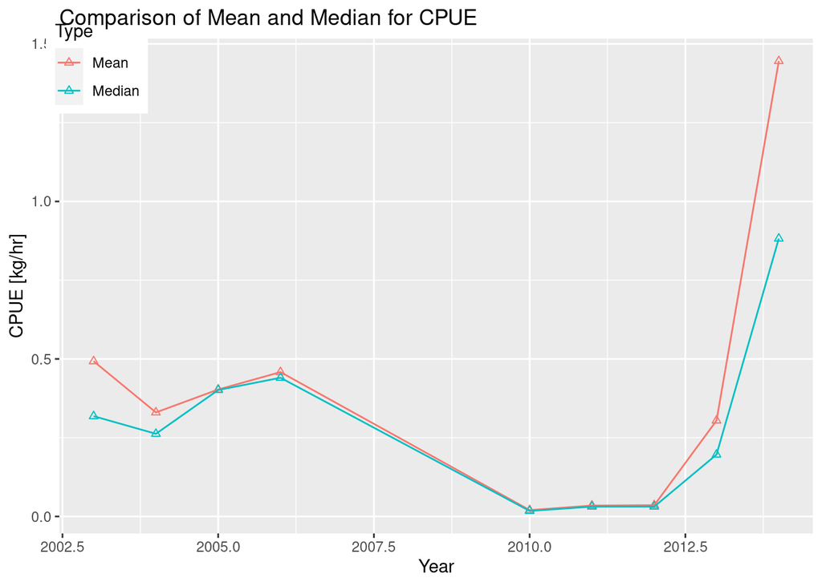

## A Brief Analysis

As can be seen, for years between 2005 and 2012 (where CPUE is relatively small) the two ‘averages’ yield very similar results.

However for years with greater CPUE such as 2003 and especially for 2013 & 2014, the mean is significantly higher. This suggests that in these years, there were a greater number of large outliers. This may have been due to a few very efficient trips which could happen by finding a shoal of *Caesio cuning* and catching a large number thereof.